# From Deprivation to Degree

Exploring the Impact of Local Income Levels on Youth Education in England

Author

Group R you OK? ：Vicky Feng , Ruyu Li , Dev Karan Gur

# 1 Executive summary

These findings highlight structural inequalities and suggest the need for targeted educational support in deprived communities.

# 2 Introduction

**Regional inequality in education** remains a pressing issue in England, particularly among young people transitioning from secondary to higher education (The Times, 2024). This study examines **whether income deprivation at the town level impacts academic outcomes for individuals aged 18 to 22.** We focus on three key milestones: Level 3 qualifications at age 18, full-time university participation at age 19, and Level 6 or higher qualification by age 22. These stages reflect national benchmarks for educational progression.

To maintain analytical consistency, cities are excluded due to their distinctive socio-demographic structures, such as dense populations and diverse education systems. We also remove entries with missing or unclear income classifications to ensure accurate results. The dataset is grouped by income level and town size, and analyzed using both summary statistics and visualizations. Trends are observed across large, medium, and small towns.

Findings reveal a consistent association: **as income deprivation decreases, educational attainment increases.** This analysis deepens our understanding of structural disadvantage and supports the development of more equitable, data-driven education policies.

# 3 Research Question

This study will focus on:

**Does the income level of a town affect the educational outcomes of young people?**

# 4 Data Loading

In this study, our group chose to **download the dataset locally** rather than relying on an online dataset. This approach **improves the reproducibility of the analysis** because local data ensures continuous access to a stable version of the data and avoids remote sources updating or deleting the data resulting in different analysis results. Also, **local datasets are more stable** as they do not rely on a network connection, which avoids interruptions due to application program interface limitations or network problems. It also improves processing speed and supports offline analysis, which is essential for **a reliable and efficient research workflow**.

We use the english_education.csv dataset downloading from the [TidyTuesday](https://github.com/rfordatascience/tidytuesday/blob/main/data/2024/2024-01-23/english_education.csv), originally sourced from [The UK Office for National Statistics (ONS)](https://www.ons.gov.uk/). The dataset contains education and deprivation data for over 1,000 English towns from 2012 to 2013 school year, offering town-level observations across key variables such as `income_flag`, `size_flag`, `level_3_at_age_18`, `activity_at_age_19_full_time_higher_education`, and `highest_level_qualification_achieved_by_age_22_level_6_or_above2`. These indicators provide a robust basis for analyzing **educational progression** in relation to **local income deprivation**.

```r
edu_df <- read_csv("../data/english_education.csv")
```

```r
selected_vars <- c(
  "income_flag",
  "level_3_at_age_18",
  "activity_at_age_19_full_time_higher_education",
  "highest_level_qualification_achieved_by_age_22_level_6_or_above",
  "size_flag"
)

edu_df_selected <- edu_df %>%
  select(all_of(selected_vars))%>%
  rename(
    level3_at_18 = level_3_at_age_18,
    uni_at_19 = activity_at_age_19_full_time_higher_education,
    level6_at_22 = highest_level_qualification_achieved_by_age_22_level_6_or_above
  )
```

# 5 Dataset introduction

## 5.1 Variables Description

```r
edu_variable_desc <- data.frame(
  Variable = c(
    "income_flag",
    "level3_at_18",
    "uni_at_19",
    "level6_at_22",
    "size_flag"
  ),
  Description = c(
    "Categorical income deprivation classification of the town (lower/mid/higher). Used as the independent grouping variable.",
    "Proportion of young people in the 2012/13 cohort who achieved Level 3 qualifications at age 18.",
    "Proportion of the cohort who entered full-time higher education by age 19.",
    "Proportion of the cohort who attained Level 6 or above qualifications (e.g., Bachelor's degree) by age 22.",
    "Town/city size classification based on 2011 census data (used to identify and exclude cities)."
  )
)

kable(
  edu_variable_desc,
  col.names = c("Variable Names", "Variable Description"),
  booktabs = TRUE,
  longtable = TRUE) %>%
  kable_styling(
    latex_options = c("striped", "hold_position", "scale_down"),
    stripe_color = "gray!15",
    font_size = 10
  ) %>%
  column_spec(1, width = "3.5cm") %>%
  column_spec(2, width = "11cm")
```

Table 1: Key Variables Used in the Analysis

| Variable Names | Variable Description |
| --- | --- |
| income_flag | Categorical income deprivation classification of the town (lower/mid/higher). Used as the independent grouping variable. |
| level3_at_18 | Proportion of young people in the 2012/13 cohort who achieved Level 3 qualifications at age 18. |
| uni_at_19 | Proportion of the cohort who entered full-time higher education by age 19. |
| level6_at_22 | Proportion of the cohort who attained Level 6 or above qualifications (e.g., Bachelor's degree) by age 22. |
| size_flag | Town/city size classification based on 2011 census data (used to identify and exclude cities). |

## 5.2 Dataset Description

The dataset contains a total of 1104 observations and 31variables.

Table 2: First 2 rows of the data

```r
head(edu_df_selected, 2)
```

```
# A tibble: 2 × 5
  income_flag              level3_at_18 uni_at_19 level6_at_22 size_flag
  <chr>                           <dbl>     <dbl>        <dbl> <chr>
1 Higher deprivation towns         50.8      30.8         NA   Small Towns
2 Mid deprivation towns            60.1      41.8         33.3 Small Towns
```

See Table 2 for the detail of the first 2 rows of the data and the types of variables in the dataset.

# 6 Methodology

```r
edu_df_selected %>%
  count(income_flag) %>%
  mutate(percentage = round(n / sum(n) * 100, 1)) %>%
  kable(
    col.names = c("Income Flag", "Count", "Percentage (%)"),
    digits = 1,
    booktabs = TRUE) %>%
  kable_styling(
    latex_options = c("striped", "hold_position"),
    stripe_color = "gray!15",
    font_size = 10
  )
```

Table 3: Proportion of Each Income Flag Category

| Income Flag | Count | Percentage (%) |
| --- | --- | --- |
| Cities | 18 | 1.6 |
| Higher deprivation towns | 433 | 39.2 |
| Lower deprivation towns | 444 | 40.2 |
| Mid deprivation towns | 205 | 18.6 |
| NA | 4 | 0.4 |

While reviewing the data (Table 3), our group discover that there is **missing data** (`NA` value) in the income categories `income_flag`. In order **not to affect the accuracy of the subsequent analysis**, this missing data will not be included in the analysis. Also, since the sample in `Cities` of `income_flag` is **too small and less representative**, it is removed in the subsequent analysis.

```r
edu_df_clean <- edu_df_selected %>%
  filter(!is.na(income_flag) & income_flag != "Cities") %>%
  mutate(income_flag = factor(income_flag,
                              levels = c("Higher deprivation towns",
                                         "Mid deprivation towns",
                                         "Lower deprivation towns")))
```

```r
table1 <- edu_df_clean %>%
  group_by(income_flag) %>%
  summarise(
    mean_level3 = mean(level3_at_18, na.rm = TRUE),
    sd_level3 = sd(level3_at_18, na.rm = TRUE),
    mean_uni19 = mean(uni_at_19, na.rm = TRUE),
    sd_uni19 = sd(uni_at_19, na.rm = TRUE),
    mean_level6 = mean(level6_at_22, na.rm = TRUE),
    sd_level6 = sd(level6_at_22, na.rm = TRUE)
  ) %>%
  rename(
    "Income Group" = income_flag,
    "Mean: Level 3 at 18" = mean_level3,
    "SD: Level 3 at 18" = sd_level3,
    "Mean: HE at 19" = mean_uni19,
    "SD: HE at 19" = sd_uni19,
    "Mean: Level 6 at 22" = mean_level6,
    "SD: Level 6 at 22" = sd_level6
  )

kable(table1,
      digits   = 2,
      booktabs = TRUE,
      longtable = TRUE
) %>%
  kable_styling(
    latex_options = c("striped", "hold_position",
                      "scale_down", "repeat_header", "longtable"),
    stripe_color = "gray!15",
    font_size = 9
  ) %>%
  column_spec(1, width = "2cm")  %>%
  column_spec(2, width = "1.8cm") %>%
  column_spec(3, width = "1.8cm") %>%
  column_spec(4, width = "1.8cm") %>%
  column_spec(5, width = "1.8cm") %>%
  column_spec(6, width = "1.8cm") %>%
  column_spec(7, width = "1.8cm")
```

Table 4: Mean and SD of Educational Outcomes by Income Group(Cities Excluded)

| Income Group | Mean: Level 3 at 18 | SD: Level 3 at 18 | Mean: HE at 19 | SD: HE at 19 | Mean: Level 6 at 22 | SD: Level 6 at 22 |
| --- | --- | --- | --- | --- | --- | --- |
| Higher deprivation towns | 41.59 | 7.35 | 27.13 | 6.69 | 23.99 | 4.92 |
| Mid deprivation towns | 47.82 | 7.59 | 31.32 | 7.20 | 27.99 | 5.69 |
| Lower deprivation towns | 57.96 | 9.68 | 40.78 | 10.33 | 35.68 | 8.33 |

For instance, the mean proportion of individuals achieving Level 3 qualifications by age 18 rises from **41.59%** in **higher deprivation** towns to **57.96%** in **lower deprivation** towns. Similar upward trends are observed for higher education participation at age 19 (**27.13%** to **40.78%**) and for achieving Level 6 qualifications by age 22 (**23.99%** to **35.68%**).

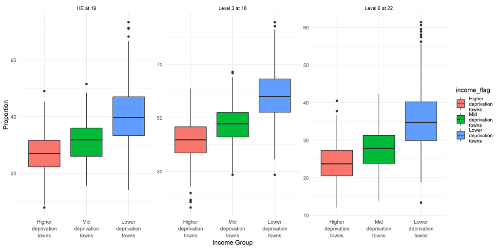

Figure 2: Educational Outcomes by Income Group(Cities Excluded)

```r
edu_long <- edu_df_clean %>%
  pivot_longer(
    cols = c(level3_at_18,
             uni_at_19,
             level6_at_22),
    names_to = "education_stage",
    values_to = "value"
  )

edu_long$income_flag <- recode(edu_long$income_flag,
  "Higher deprivation towns" = "Higher\ndeprivation\ntowns",
  "Mid deprivation towns" = "Mid\ndeprivation\ntowns",
  "Lower deprivation towns" = "Lower\ndeprivation\ntowns"
)

edu_long$education_stage <- recode(edu_long$education_stage,
  "level3_at_18" = "Level 3 at 18",
  "uni_at_19" = "HE at 19",
  "level6_at_22" = "Level 6 at 22"
)

ggplot(edu_long, aes(x = income_flag, y = value, fill = income_flag)) +
  geom_boxplot() +
  facet_wrap(~education_stage, scales = "free_y") +
  labs(x = "Income Group", y = "Proportion") +
  theme_minimal() +
  theme(axis.text.x = element_text(size = 9, lineheight = 1.1))
```

Figure 2 illustrates **a clear upward trend in educational attainment as town income levels increase**. In all three stages, young people in lower deprivation towns consistently outperform their peers in higher deprivation towns.

# 7 Result

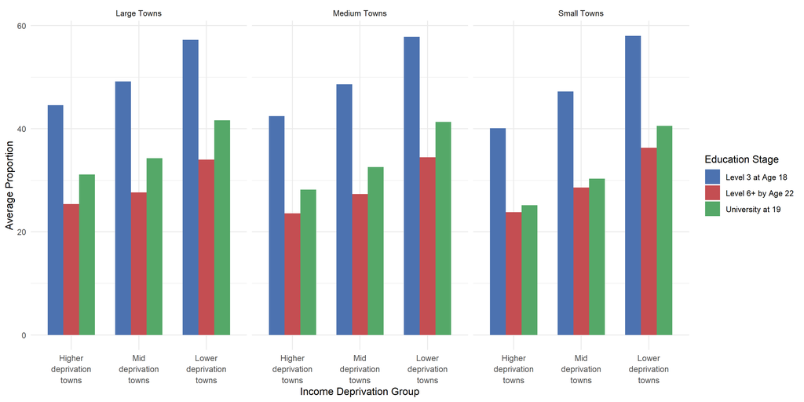

(1) Comparison of educational outcomes across income levels and town sizes

Figure 3: Educational Attainment by Income Deprivation Level and Town Size (Cities Excluded)

```r
summary_df <- edu_df_clean %>%
  group_by(income_flag, size_flag) %>%
  summarise(
    level3 = mean(level3_at_18, na.rm = TRUE),
    uni19 = mean(uni_at_19, na.rm = TRUE),
    level6 = mean(level6_at_22, na.rm = TRUE)
  ) %>%
  pivot_longer(
    cols = c(level3, uni19, level6),
    names_to = "education_stage",
    values_to = "mean_value"
  )

summary_df$education_stage <- recode(summary_df$education_stage,
  "level3" = "Level 3 at Age 18",
  "uni19" = "University at 19",
  "level6" = "Level 6+ by Age 22"
)

summary_df$income_flag <- recode(summary_df$income_flag,
  "Higher deprivation towns" = "Higher\ndeprivation\ntowns",
  "Mid deprivation towns" = "Mid\ndeprivation\ntowns",
  "Lower deprivation towns" = "Lower\ndeprivation\ntowns"
)

ggplot(summary_df, aes(x = income_flag, y = mean_value, fill = education_stage)) +
  geom_col(position = "dodge", width = 0.7) +
  facet_wrap(~size_flag) +
  labs(
    x = "Income Deprivation Group",
    y = "Average Proportion",
    fill = "Education Stage"
  ) +
  scale_fill_manual(
    values = c(
      "Level 3 at Age 18" = "#4C72B0",
      "University at 19" = "#55A868",
      "Level 6+ by Age 22" = "#C44E52"
    )
  ) +
  theme_minimal() +
  theme(axis.text.x = element_text(size = 9, lineheight = 1.1))
```

As shown in Figure 3, **educational attainment increases consistently as income deprivation decreases, across all town sizes**. Towns with **lower deprivation levels** demonstrate the **highest average proportions** of students achieving Level 3 qualifications at age 18, entering university at age 19, and obtaining Level 6 or higher qualifications by age 22.

This pattern holds for large, medium, and small towns, though the gap between high and low deprivation groups appears most pronounced in small towns, particularly at the Level 6+ stage. In small towns, the difference in university attainment between high and low deprivation groups exceeds 10 percentage points.

These results **reinforce a strong association between local income levels and youth educational outcomes**, and suggest that deprivation may have an even stronger impact in smaller towns.

# 8 Discussion

Our analysis reveals a consistent trend: towns with lower levels of income deprivation demonstrate stronger educational outcomes at ages 18, 19, and 22. This association holds across all town sizes and is particularly pronounced in smaller towns, where the disparity in Level 6 qualifications is most significant. These findings align with recent research by the UK Office for National Statistics (ONS), which suggests that less deprived areas may offer more supportive conditions for academic progression.

Nonetheless, several limitations of this study must be acknowledged. First, as an observational analysis, our findings illustrate correlation rather than causation. While the relationship between deprivation and lower attainment is strong, we cannot definitively claim that income deprivation directly causes poorer educational outcomes. Second, the use of broad categorical income groupings may mask finer-grained local differences, potentially obscuring key contextual factors. Third, we deliberately excluded cities to ensure analytical consistency; however, this decision limits the generalisability of our findings, particularly to urban populations who often face distinct educational barriers. Lastly, the dataset is limited to a single cohort of students from the 2012/13 academic year, meaning it may not capture evolving socioeconomic dynamics or long-term trends in educational performance.

Despite these constraints, the findings clearly highlight structural inequalities that disadvantage youth in more deprived towns. This underscores the need for targeted, evidence-based policy interventions to reduce educational disparities. Future research should incorporate longitudinal data and more granular socioeconomic indicators to deepen our understanding of these patterns and inform more effective policy responses.

# 9 Conclusion

# 10 Recommendations

To address the disparities observed, education policy should **prioritize support for students in high-deprivation towns**. This may include:

- Enhance educational funding and targeted support in high-deprivation towns
- Expand access programs to encourage university progression
- Better access to higher education pathways
- Integrate deprivation indicators into education planning and policy to ensure equitable resource distribution

In addition, **future research** should expand the study’s dataset. There is a need to include **multiple clusters and urban areas** and to **integrate qualitative indicators** such as school quality and student support services as study variables. These efforts will contribute to **a more comprehensive understanding of how income poverty affects educational trajectories** and inform the development of more equitable education strategies.

# 11 Citation

**R and R Package**

1. R Core Team (2025). *R: A Language and Environment for Statistical Computing*. R Foundation for Statistical Computing, Vienna, Austria. https://www.R-project.org/.
2. Wickham H, François R, Henry L, Müller K, Vaughan D (2023). *dplyr: A Grammar of Data Manipulation*. R package version 1.1.4, https://CRAN.R-project.org/package=dplyr.
3. H. Wickham. ggplot2: Elegant Graphics for Data Analysis. Springer-Verlag New York, 2016.
4. Wickham H, Hester J, Bryan J (2024). *readr: Read Rectangular Text Data*. R package version 2.1.5, https://CRAN.R-project.org/package=readr.
5. Wickham H, Vaughan D, Girlich M (2024). *tidyr: Tidy Messy Data*. R package version 1.3.1, https://CRAN.R-project.org/package=tidyr.
6. Xie Y (2024). *knitr: A General-Purpose Package for Dynamic Report Generation in R*. R package version 1.49, https://yihui.org/knitr/.

   Yihui Xie (2015) Dynamic Documents with R and knitr. 2nd edition. Chapman and Hall/CRC. ISBN 978-1498716963

   Yihui Xie (2014) knitr: A Comprehensive Tool for Reproducible Research in R. In Victoria Stodden, Friedrich Leisch and Roger D. Peng, editors, Implementing Reproducible Computational Research. Chapman and Hall/CRC. ISBN 978-1466561595
7. Zhu H (2024). *kableExtra: Construct Complex Table with ‘kable’ and Pipe Syntax*. R package version 1.4.0, https://github.com/haozhu233/kableExtra, http://haozhu233.github.io/kableExtra/.

**Website**

1. Office for National Statistics. (2023, July 25). *Why do children and young people in smaller towns do better academically than those in larger towns?* https://www.ons.gov.uk/peoplepopulationandcommunity/educationandchildcare/articles/whydochildrenandyoungpeopleinsmallertownsdobetteracademicallythanthoseinlargertowns/2023-07-25
2. The Times. (2024, August 14). University offers at record high as inequality in degree entry grows. Retrieved from https://www.thetimes.co.uk/article/university-offers-at-record-high-as-inequality-in-access-grows-ttj9scz6b